# Point Cloud Filters & Pipelines

### *Bradley J Chambers, DigitalGlobe*

[figure not shown]

##### Or, how I came to love Jupyter Notebooks.

# Overview

- Status of PCL Filters
- Filter-only Pipelines
- Python Package
- `pdal-notebook` Docker Image
- IPython/Jupyter Examples
- DimRange
- Ignore
- Last returns / Classify / Extract

# Status of PCL Filters

- FOSS4G 2016 we preached PDAL + PCL
- Then PDAL v1.2
- Now PDAL v1.5
- Native PDAL variants of PCL filters
- New to PDAL (replaces PCL)
  - `filters.pmf` (was `filters.ground`)
  - `filters.outlier` (was `filters.radiusoutlier` and `filters.statisticaloutlier`)
  - `filters.hag` (was `filters.height`)
  - `filters.sample` (was `filters.dartsample`)
- Kept PCD reader & writer, and some seldom used filters
- PCL JSON specifcation bumped to v0.2 - easier to embed in PDAL JSON
- Removed the PCL Visualizers

# Filter-only Pipelines

We can now do filter-only pipelines. Why is that important? Well, you could always create the pipeline, and do substitution:

```
pdal pipeline pipeline.json \
     --readers.las.filename=input.las --writers.las.filename=output.las
```

Is now.

`pdal translate input.las output.las --json pipeline.json`

# Python Package

The PDAL Python [package](https://pypi.python.org/pypi/PDAL) can be installed via [pip](https://pip.pypa.io/en/stable/).

`pip install pdal`

Once installed, simply

```python
import pdal
```

# `pdal-notebook` Docker Image

- `pdal/pdal` image has existed for some time
- Rational for `pdal-notebook` is to layer on all the necessary pieces to be able to use PDAL and the PDAL python package within a Jupyter notebook, with some extra goodies

# IPython/Jupyter Examples

The remainder of the presentation will leverage our `pdal-notebook` and present examples in the context of the PDAL Python package (though CLI samples will be provided as well).

## Creating a Pipeline

Start by importing the PDAL package.

```python
import pdal
```

Define the pipeline JSON.

```python
json = u'''
{
  "pipeline":[
    "./data/isprs/samp11-utm.laz"
  ]
}'''
```

This JSON description of the pipeline is passed directly to the `pdal.Pipeline()` constructor.

```python
p = pdal.Pipeline(json)
```

## Validating & Executing the Pipeline

We can check that we have defined a valid pipeline.

```python
valid = p.validate()
print('Is pipeline valid? %s' % valid)
```

```
Is pipeline valid? True
```

Next, we execute the pipeline.

```python
count = p.execute()
print('Pipeline processed %d points.' % count)
```

```
Pipeline processed 38010 points.
```

```python
arr = p.arrays[0]
print('Pipeline contains %d array(s) of type %s.' % (len(p.arrays), type(arr)))
```

```
Pipeline contains 1 array(s) of type <type 'numpy.ndarray'>.
```

## Use the `ndarray`

While it is possible to work with the `numpy.ndarray` directly, for example printing the first record

```python
print(arr[0])
```

```
(512743.63, 5403547.33, 308.68, 0, 1, 1, 0, 0, 2, 0.0, 0, 0)
```

printing the first 10 X values

```python
print(arr['X'][:10])
```

```
[ 512743.63  512743.62  512743.61  512743.6   512743.6   512741.5   512741.5
  512741.49  512741.48  512741.47]
```

or computing the mean of all Z values

```python
print(arr['Z'].mean())
```

```
356.17143357
```

## Or Pandas!

We can also leverage other Python packages like Pandas to read the data

```python
import pandas as pd
samp11 = pd.DataFrame(arr)
```

## Print Records

```python
samp11.head()
```

|  | X | Y | Z | Intensity | ReturnNumber | NumberOfReturns | ScanDirectionFlag | EdgeOfFlightLine | Classification | ScanAngleRank | UserData | PointSourceId |
| --- | --- | --- | --- | --- | --- | --- | --- | --- | --- | --- | --- | --- |
| 0 | 512743.63 | 5403547.33 | 308.68 | 0 | 1 | 1 | 0 | 0 | 2 | 0.0 | 0 | 0 |
| 1 | 512743.62 | 5403547.33 | 308.70 | 0 | 1 | 1 | 0 | 0 | 2 | 0.0 | 0 | 0 |
| 2 | 512743.61 | 5403547.33 | 308.72 | 0 | 1 | 1 | 0 | 0 | 2 | 0.0 | 0 | 0 |
| 3 | 512743.60 | 5403547.34 | 308.68 | 0 | 1 | 1 | 0 | 0 | 2 | 0.0 | 0 | 0 |
| 4 | 512743.60 | 5403547.33 | 308.73 | 0 | 1 | 1 | 0 | 0 | 2 | 0.0 | 0 | 0 |

```python
samp11.tail()
```

|  | X | Y | Z | Intensity | ReturnNumber | NumberOfReturns | ScanDirectionFlag | EdgeOfFlightLine | Classification | ScanAngleRank | UserData | PointSourceId |
| --- | --- | --- | --- | --- | --- | --- | --- | --- | --- | --- | --- | --- |
| 38005 | 512834.60 | 5403818.01 | 375.55 | 1 | 1 | 1 | 0 | 0 | 0 | 0.0 | 0 | 0 |
| 38006 | 512834.66 | 5403819.08 | 374.56 | 1 | 1 | 1 | 0 | 0 | 0 | 0.0 | 0 | 0 |
| 38007 | 512834.76 | 5403828.06 | 374.41 | 1 | 1 | 1 | 0 | 0 | 0 | 0.0 | 0 | 0 |
| 38008 | 512834.76 | 5403842.65 | 377.74 | 1 | 1 | 1 | 0 | 0 | 0 | 0.0 | 0 | 0 |
| 38009 | 512834.48 | 5403849.42 | 385.57 | 1 | 1 | 1 | 0 | 0 | 0 | 0.0 | 0 | 0 |

## Summarize

```python
samp11.describe()
```

|  | X | Y | Z | Intensity | ReturnNumber | NumberOfReturns | ScanDirectionFlag | EdgeOfFlightLine | Classification | ScanAngleRank | UserData | PointSourceId |
| --- | --- | --- | --- | --- | --- | --- | --- | --- | --- | --- | --- | --- |
| count | 38010.000000 | 3.801000e+04 | 38010.000000 | 38010.000000 | 38010.0 | 38010.0 | 38010.0 | 38010.0 | 38010.000000 | 38010.0 | 38010.0 | 38010.0 |
| mean | 512767.010570 | 5.403708e+06 | 356.171434 | 0.426835 | 1.0 | 1.0 | 0.0 | 0.0 | 1.146330 | 0.0 | 0.0 | 0.0 |
| std | 38.570375 | 8.587360e+01 | 29.212680 | 0.494624 | 0.0 | 0.0 | 0.0 | 0.0 | 0.989249 | 0.0 | 0.0 | 0.0 |
| min | 512700.870000 | 5.403547e+06 | 295.250000 | 0.000000 | 1.0 | 1.0 | 0.0 | 0.0 | 0.000000 | 0.0 | 0.0 | 0.0 |
| 25% | 512733.530000 | 5.403645e+06 | 329.060000 | 0.000000 | 1.0 | 1.0 | 0.0 | 0.0 | 0.000000 | 0.0 | 0.0 | 0.0 |
| 50% | 512766.940000 | 5.403705e+06 | 356.865000 | 0.000000 | 1.0 | 1.0 | 0.0 | 0.0 | 2.000000 | 0.0 | 0.0 | 0.0 |
| 75% | 512799.900000 | 5.403790e+06 | 385.860000 | 1.000000 | 1.0 | 1.0 | 0.0 | 0.0 | 2.000000 | 0.0 | 0.0 | 0.0 |
| max | 512834.760000 | 5.403850e+06 | 404.080000 | 1.000000 | 1.0 | 1.0 | 0.0 | 0.0 | 2.000000 | 0.0 | 0.0 | 0.0 |

## Analyze

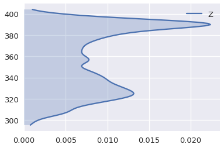

```python
%matplotlib inline
import seaborn as sns
sns.set(color_codes=True)
sns.set_context("talk")
sns.kdeplot(samp11['Z'], cut=0, shade=True, vertical=True);
```

## CLI Access

```python
!pdal
```

```
Usage:
  pdal <options>
  pdal <command> <command options>
  --command        The PDAL command
  --debug          Sets the output level to 3 (option deprecated)
  --verbose, -v    Sets the output level (0-8)
  --drivers        List available drivers
  --help, -h       Display help text
  --list-commands  List available commands
  --version        Show program version
  --options        Show options for specified driver (or 'all')
  --log            Log filename (accepts stderr, stdout, stdlog, devnull as
      special cases)

The following commands are available:
   - kernels.cpd
   - kernels.delta
   - kernels.density
   - kernels.diff
   - kernels.ground
   - kernels.hausdorff
   - kernels.info
   - kernels.merge
   - kernels.pcl
   - kernels.pipeline
   - kernels.random
   - kernels.smooth
   - kernels.sort
   - kernels.split
   - kernels.tindex
   - kernels.translate
See http://pdal.io/apps/ for more detail
```

## Using JQ to Parse `pdal info`

```python
!pdal info ./data/isprs/samp11-utm.laz | jq .stats.bbox.native.bbox
```

```
{
  "maxx": 512834.76,
  "maxy": 5403849.99,
  "maxz": 404.08,
  "minx": 512700.87,
  "miny": 5403547.26,
  "minz": 295.25
}
```

## Searching Near a Point

```python
med = samp11[['X','Y','Z']].median()
print(med)
```

```
X     512766.940
Y    5403705.460
Z        356.865
dtype: float64
```

```python
from scipy import spatial
tree = spatial.cKDTree(samp11[['X','Y','Z']])
dists, idx = tree.query(med, k=3)
print(dists)
```

```
[ 0.6213091   1.37645378  1.51757207]
```

```python
samp11.iloc[idx]
```

|  | X | Y | Z | Intensity | ReturnNumber | NumberOfReturns | ScanDirectionFlag | EdgeOfFlightLine | Classification | ScanAngleRank | UserData | PointSourceId |
| --- | --- | --- | --- | --- | --- | --- | --- | --- | --- | --- | --- | --- |
| 31897 | 512767.16 | 5403706.02 | 357.02 | 1 | 1 | 1 | 0 | 0 | 0 | 0.0 | 0 | 0 |
| 31881 | 512767.93 | 5403706.29 | 356.39 | 1 | 1 | 1 | 0 | 0 | 0 | 0.0 | 0 | 0 |
| 31972 | 512765.75 | 5403706.19 | 356.27 | 1 | 1 | 1 | 0 | 0 | 0 | 0.0 | 0 | 0 |

# DimRange

A [DimRange](https://www.pdal.io/stages/filters.range.html#ranges) is a

- named dimension, and
- range of values.

Bounds can be inclusive (`[]`) or exclusive (`()`).

Ranges can be negated (`!`).

For example,

- `Z[10:]` selects all points with Z greater than or equal to 10
- `Classification[2:2]` selects all points with classification of 2
- `Red!(20:40]` selects all points with red values less than or equal to 20 as well as those with values greater than 40

Commonly used in both `filters.range`

```python
json = u'''
{
  "pipeline":[
    {
      "type":"filters.range",
      "limits":"Z[10:]"
    }
  ]
}
'''
```

and `filters.assign`.

```python
json = u'''
{
  "pipeline":[
    {
      "type":"filters.assign",
      "assignment":"Classification[:]=0"
    }
  ]
}
'''
```

# Ignore

Two of PDAL's ground segmentation filters, `filters.pmf` and `filters.smrf`, can now specify a `DimRange` via the `ignore` parameter to specify points that should be ignored during processing.

A common use case for this is to ignore points that have been previously marked as noise. In prior versions of PDAL, we had to filter noise out completely prior to ground segmentation.

```python
json = u'''
{
  "pipeline":[
    {
      "type":"filters.range",
      "limits":"Classification![7:7]"
    },
    {
      "type":"filters.smrf"
    }
  ]
}
'''
```

Which of course means those noise points are gone forever.

Now, with `ignore` we can

```python
json = u'''
{
  "pipeline":[
    {
      "type":"filters.smrf",
      "ignore":"Classification[7:7]"
    }
  ]
}
'''
```

Which allows us to retain noise points without having them impact the ground segmentation step.

## Height Above Ground

To compute `HeightAboveGround` we will use two PDAL filters, first [SMRF](https://pdal.io/stages/filters.smrf.html) to segment ground and non-ground returns, and [HAG](https://pdal.io/stages/filters.hag.html) to estimate the `HeightAboveGround` using the return information.

```python
json = u'''
{
  "pipeline":[
    "./data/isprs/samp11-utm.laz",
    {
      "type":"filters.smrf"
    },
    {
      "type":"filters.hag"
    }
  ]
}'''

p = pdal.Pipeline(json)
count = p.execute()
df = pd.DataFrame(p.arrays[0])
```

Note that this is equivalent to

```python
!pdal translate ./data/isprs/samp11-utm.laz ./data/foo.laz smrf hag
```

Recall the kernel density of raw elevations...

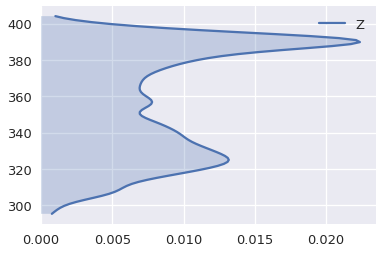

```python
sns.kdeplot(df['Z'], cut=0, shade=True, vertical=True);
```

Now, consider the `HeightAboveGround` dimension.

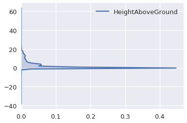

```python
sns.kdeplot(df['HeightAboveGround'], cut=0, shade=True, vertical=True);
```

```python
json = u'''
{
  "pipeline":[
    "./data/isprs/samp11-utm.laz",
    {
      "type":"filters.smrf"
    },
    {
      "type":"filters.hag"
    },
    {
      "type":"filters.range",
      "limits":"Classification[1:1]"
    }
  ]
}'''

p = pdal.Pipeline(json)
count = p.execute()
df = pd.DataFrame(p.arrays[0])
```

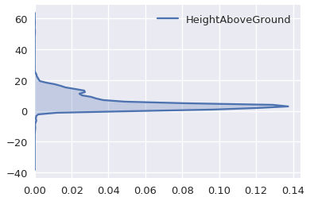

```python
sns.kdeplot(df['HeightAboveGround'], cut=0, shade=True, vertical=True);
```

```python
json = u'''
{
  "pipeline":[
    "./data/isprs/samp11-utm.laz",
    {
      "type":"filters.elm"
    },
    {
      "type":"filters.range",
      "limits":"Classification![7:7]"
    },
    {
      "type":"filters.smrf"
    },
    {
      "type":"filters.hag"
    },
    {
      "type":"filters.range",
      "limits":"Classification[1:1]"
    }
  ]
}'''

p = pdal.Pipeline(json)
count = p.execute()
df = pd.DataFrame(p.arrays[0])
```

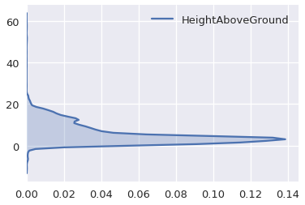

```python
sns.kdeplot(df['HeightAboveGround'], cut=0, shade=True, vertical=True);
```

```python
df[['HeightAboveGround']].describe()
```

|  | HeightAboveGround |
| --- | --- |
| count | 15607.000000 |
| mean | 5.467956 |
| std | 5.006438 |
| min | -13.280000 |
| 25% | 2.110000 |
| 50% | 3.870000 |
| 75% | 7.810000 |
| max | 63.700000 |

## Removing Noise

This tutorial is meant to walk through the use of and theory behind PDAL's `outlier` filter.

- Statistical Outlier Filter
- Radius Outlier Filter

### Statistical Outlier Filter

The basic idea of a statistical outlier removal has been implemented in both [PCL](http://www.pointclouds.org/documentation/tutorials/statistical_outlier.php#statistical-outlier-removal) and [PDAL](https://www.pdal.io/stages/filters.outlier.html).

We begin by computing the mean distance $\mu_i$ to each of the $k$ nearest neighbors for each point.

Next, we use the pointwise mean distances to compute the global mean

$$\overline{\mu} = \frac{1}{N} \sum_{i=1}^N \mu_i$$

and standard deviation

$$\sigma = \sqrt{\frac{1}{N-1} \sum_{i=1}^N (\mu_i - \overline{\mu})^2}$$

A threshold is then formed by

$$\overline{\mu} + 3\sigma$$

Any point whose mean distance $\mu_i$ exceeds this threshold is then labeled as noise.

Let's begin by iterating through our DataFrame, keeping track of the mean distance to our eight nearest neighbors.

```python
import numpy as np
dists = []
for _, point in samp11[['X','Y','Z']].iterrows():
    dist, _ = tree.query(point, k=9)
    dists = np.append(dists, dist[1:].mean())
```

The KDE plot of the mean distances looks something like this.

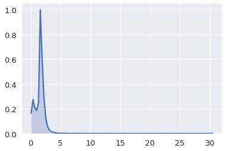

```python
sns.kdeplot(dists, cut=0, shade=True);
```

Now, we compute the threshold as described.

```python
threshold = dists.mean()+3*dists.std()
noise = dists[dists>threshold]
signal = dists[dists<=threshold]
print(noise.size, "points detected with a "
      "mean distance exceeding the global threshold of", threshold)
```

```
241 points detected with a mean distance exceeding the global threshold of 3.81763516967
```

Now our KDE plot of mean distances looks like this.

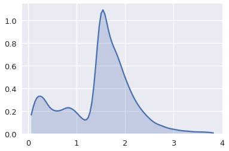

```python
sns.kdeplot(signal, cut=0, shade=True);
```

```python
!pdal translate ./data/isprs/samp11-utm.laz ./data/foo.laz assign outlier \
  --filters.assign.assignment="Classification[:]=0" \
  --filters.outlier.method="statistical" \
  --filters.outlier.multiplier=3 \
  --filters.outlier.mean_k=8 \
  --verbose 5
```

```
(pdal translate filters.outlier Debug) 		Labeled 241 outliers as noise!
(pdal translate writers.las Debug) Wrote 38010 points to the LAS file
```

```python
json = u'''
{
  "pipeline":[
    "./data/isprs/samp11-utm.laz",
    {
      "type":"filters.assign",
      "assignment":"Classification[:]=0"
    },
    {
      "type": "filters.outlier",
      "method": "statistical",
      "multiplier": 3,
      "mean_k": 8
    }
  ]
}'''

p = pdal.Pipeline(json)
p.loglevel = 8
p.execute()
print(p.log)
```

```
(pypipeline filters.outlier Debug) 		Labeled 241 outliers as noise!
```